# Figures for the MBR Manuscript

This vignette produces the graphs included in the initial MBR manuscript.

## Figure 1: Cartesian Rolling - 2005 Version

Figure 1: Raw monthly birth rates (General Fertility Rates; GFR’s) for Oklahoma County, 1990-1999, plotted in a linear plot; the “bombing effect” is located ten months after the Oklahoma City bombing.

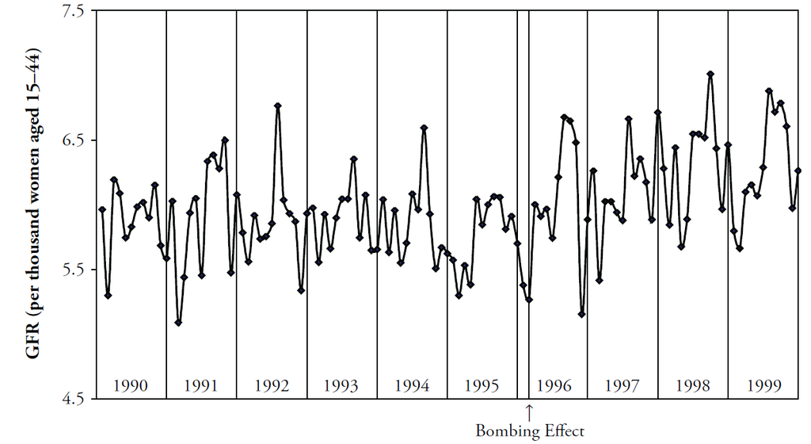

## Figure 2: Cartesian Rolling - 2014 Version

Smoothed monthly birth rates (General Fertility Rates; GFRs) for Oklahoma County, 1990-1999, plotted in a linear plot. The top plot shows the connected raw data with a February smoother; the middle plot shows smoothing with a 12-month moving average, blue/green line, superimposed on a February smoother, red line); the bottom plot shows the smoothers and confidence bands, which are H-spreads defined using the distribution of GFR’s for the given month and 11 previous months.

First, some R packages are loaded, and some variables and functions are defined.

```r
change_month <- base::as.Date("1996-02-15") #as.Date("1995-04-19") + lubridate::weeks(39) = "1996-01-17"
set.seed(444) # So bootstrap won't trigger a git diff

vp_layout <- function(x, y) {
  grid::viewport(layout.pos.row=x, layout.pos.col=y)
}

full_spread <- function( scores ) {
  return( base::range(scores) ) #A new function isn't necessary.  It's defined in order to be consistent.
}
h_spread <- function( scores ) {
  return( stats::quantile(x=scores, probs=c(.25, .75)) )
}
se_spread <- function( scores ) {
  return( base::mean(scores) + base::c(-1, 1) * stats::sd(scores) / base::sqrt(base::sum(!base::is.na(scores))) )
}
boot_spread <- function( scores, conf=.68 ) {
  plugin <- function( d, i ) {
    base::mean(d[i])
  }

  distribution <- boot::boot(data=scores, plugin, R=99) #999 for the publication
  ci <- boot::boot.ci(distribution, type = c("bca"), conf=conf)
  return( ci$bca[4:5] ) #The fourth & fifth elements correspond to the lower & upper bound.
}

dark_theme <- ggplot2::theme(
  axis.title          = ggplot2::element_text(color="gray30", size=9),
  # axis.text.x         = ggplot2::element_text(color="gray30", margin   = grid::unit(.00001, "cm"), hjust=0),
  # axis.text.y         = ggplot2::element_text(color="gray30", margin   = grid::unit(.00001, "cm")),
  axis.text.x         = ggplot2::element_text(color="gray30", hjust=0),
axis.text.y         = ggplot2::element_text(color="gray30"),
  axis.ticks.length   = grid::unit(0, "cm"),
#   panel.grid.minor.y  = element_line(color="gray95", linewidth=.1),
#   panel.grid.major    = element_line(color="gray90", linewidth=.1),
  panel.spacing       = grid::unit(c(0, 0, 0, 0), "cm"),
  plot.margin         = grid::unit(c(0, 0, 0, 0), "cm")
)
# qplot(mtcars$hp) + dark_theme

light_theme <- dark_theme + ggplot2::theme(
  axis.title          = ggplot2::element_text(color="gray80", size=9),
  axis.text.x         = ggplot2::element_text(color="gray80", hjust=0),
  axis.text.y         = ggplot2::element_text(color="gray80"),
  panel.grid.minor.y  = ggplot2::element_line(color="gray99", linewidth=.1),
  panel.grid.major    = ggplot2::element_line(color="gray95", linewidth=.1)
)
date_sequence <- base::seq.Date(from=base::as.Date("1990-01-01"), to=base::as.Date("1999-01-01"), by="years")
x_scale       <- ggplot2::scale_x_date(breaks=date_sequence, labels=scales::date_format("%Y"))
x_scale_blank  <- ggplot2::scale_x_date(breaks=date_sequence, labels=NULL) #This keeps things proportional down the three frames.
```

### Individual Components

Here is the basic linear rolling graph. It doesn’t require much specification, and will work with a wide range of appropriate datasets. This first (unpublished) graph displays all components.

```r
# ds_linear_all <- utils::read.csv("./Datasets/county_month_birth_rate_2005_version.csv", stringsAsFactors=FALSE)
# ds_linear_all$date <- base::as.Date(ds_linear_all$date)
# ds_linear_okc <- ds_linear_all[ds_linear_all$county_name=="oklahoma", ]

# Uncomment the next two lines to use the version built into the package.  By default, it uses the
# CSV to promote reproducible research, since the CSV format is more open and accessible to more software.

ds_linear_all <-
  county_month_birth_rate_2005_version |>
  tibble::as_tibble()
# ds_linear_all <- county_month_birth_rate_2005_version
ds_linear_okc <- ds_linear_all[ds_linear_all$county_name=="oklahoma", ]

# ds_linear_okc <-
#   ds_linear_all |>
#   dplyr::filter(county_name == "oklahoma")

ds_linear_okc <- augment_year_data_with_month_resolution(ds_linear=ds_linear_okc, date_name="date")

portfolio_cartesian <- annotate_data(ds_linear_okc, dv_name="birth_rate", center_function=stats::median, spread_function=h_spread)

cartesian_rolling(
  ds_linear = portfolio_cartesian$ds_linear,
  x_name = "date",
  y_name = "birth_rate",
  stage_id_name = "stage_id",
  change_points = change_month,
  change_point_labels = "Bombing Effect"
)
```

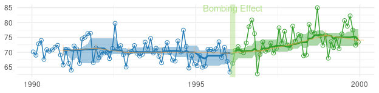

The version for the manuscript was tweaked to take advantage of certain features of the dataset. This is what it looks like when all three stylized panels are combined.

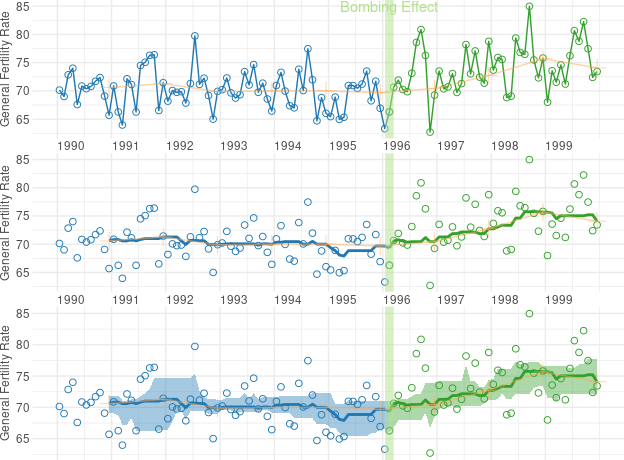

```r
top_panel <- Wats::cartesian_rolling(
  ds_linear = portfolio_cartesian$ds_linear,
  x_name = "date",
  y_name = "birth_rate",
  stage_id_name = "stage_id",
  change_points = change_month,
  y_title = "General Fertility Rate",
  change_point_labels = "Bombing Effect",
  draw_rolling_band = FALSE,
  draw_rolling_line = FALSE
)

middle_panel <- Wats::cartesian_rolling(
  ds_linear = portfolio_cartesian$ds_linear,
  x_name = "date",
  y_name = "birth_rate",
  stage_id_name = "stage_id",
  change_points = change_month,
  y_title = "General Fertility Rate",
  change_point_labels = "",
  draw_rolling_band = FALSE,
  draw_jagged_line = FALSE
)

bottom_panel <- Wats::cartesian_rolling(
  ds_linear = portfolio_cartesian$ds_linear,
  x_name = "date",
  y_name = "birth_rate",
  stage_id_name = "stage_id",
  change_points = change_month,
  y_title = "General Fertility Rate",
  change_point_labels = "",
#   draw_rolling_band = FALSE,
  draw_jagged_line = FALSE
)

top_panel <- top_panel + x_scale + dark_theme
middle_panel <- middle_panel + x_scale + dark_theme
bottom_panel <- bottom_panel + x_scale_blank + dark_theme

grid::grid.newpage()
grid::pushViewport(grid::viewport(layout=grid::grid.layout(3,1)))
print(top_panel, vp=vp_layout(1, 1))
print(middle_panel, vp=vp_layout(2, 1))
print(bottom_panel, vp=vp_layout(3, 1))
grid::popViewport()
```

## Figure 4: Cartesian Periodic

Cartesian plot of the GFR time series data in Oklahoma County, with H-spread Bands superimposed.

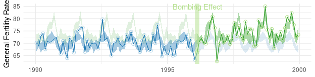

```r
cartesian_periodic <- Wats::cartesian_periodic(
  portfolio_cartesian$ds_linear,
  portfolio_cartesian$ds_periodic,
  x_name = "date",
  y_name = "birth_rate",
  stage_id_name = "stage_id",
  change_points = change_month,
  change_point_labels = "Bombing Effect",
  y_title = "General Fertility Rate",
  draw_periodic_band = TRUE #The only difference from the simple linear graph above
)
print(cartesian_periodic)
```

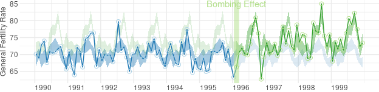

```r
cartesian_periodic <- cartesian_periodic + x_scale + dark_theme
print(cartesian_periodic)
```

## Figure 5: Polar Periodic

Wrap Around Time Series (WATS Plot) of the Oklahoma City GFR data, 1990-1999

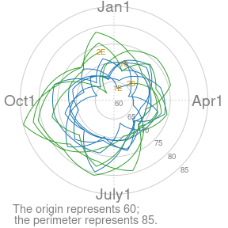

```r
portfolio_polar <- polarize_cartesian(
  ds_linear = portfolio_cartesian$ds_linear,
  ds_stage_cycle = portfolio_cartesian$ds_stage_cycle,
  y_name = "birth_rate",
  stage_id_name = "stage_id",
  plotted_point_count_per_cycle = 7200
)

grid::grid.newpage()
polar_periodic(
  ds_linear = portfolio_polar$ds_observed_polar,
  ds_stage_cycle = portfolio_polar$ds_stage_cycle_polar,
  y_name = "radius",
  stage_id_name = "stage_id",
  draw_periodic_band = FALSE,
  draw_stage_labels = TRUE,
  draw_radius_labels = TRUE,
  cardinal_labels = c("Jan1", "Apr1", "July1", "Oct1")
)
```

## Figure 6: WATS and Cartesian

Wrap Around Time Series (WATS Plot) of the Oklahoma City GFR data, 1990-1999

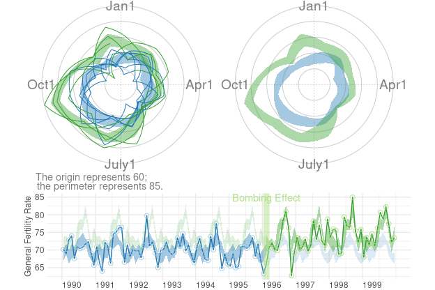

```r
portfolio_polar <- Wats::polarize_cartesian(
  ds_linear = portfolio_cartesian$ds_linear,
  ds_stage_cycle = portfolio_cartesian$ds_stage_cycle,
  y_name = "birth_rate",
  stage_id_name = "stage_id",
  plotted_point_count_per_cycle = 7200
)

grid::grid.newpage()
grid::pushViewport(grid::viewport(
  layout=grid::grid.layout(
    nrow = 2, ncol = 2, respect = TRUE,
    widths = unit(c(1, 1), c("null", "null")),
    heights = unit(c(1, .5), c("null", "null"))
  ),
  gp = grid::gpar(cex=1, fill=NA)
))

## Create top left panel
grid::pushViewport(grid::viewport(layout.pos.col=1, layout.pos.row=1))
top_left_panel <- Wats::polar_periodic(
  ds_linear = portfolio_polar$ds_observed_polar,
  ds_stage_cycle_polar = portfolio_polar$ds_stage_cycle_polar,
  y_name = "radius",
  stage_id_name = "stage_id", #graph_ceiling=7,
  cardinal_labels = c("Jan1", "Apr1", "July1", "Oct1")
)
grid::upViewport()

## Create top right panel
grid::pushViewport(grid::viewport(layout.pos.col=2, layout.pos.row=1))
top_right_panel <- Wats::polar_periodic(
  ds_linear = portfolio_polar$ds_observed_polar,
  ds_stage_cycle_polar = portfolio_polar$ds_stage_cycle_polar,
  y_name = "radius",
  stage_id_name = "stage_id", #graph_ceiling=7,
  draw_observed_line = FALSE,
  cardinal_labels = c("Jan1", "Apr1", "July1", "Oct1"),
  origin_label = NULL
)
grid::upViewport()

## Create bottom panel
grid::pushViewport(grid::viewport(layout.pos.col=1:2, layout.pos.row=2, gp=grid::gpar(cex=1)))
print(cartesian_periodic, vp=vp_layout(x=1:2, y=2)) #Print across both columns of the bottom row.
grid::upViewport()
```

## Figure 7: County Comparison

This figure compares Oklahoma County against the (other) largest urban counties.

```r
# ds_linear_all <- Wats::augment_year_data_with_month_resolution(ds_linear=county_month_birth_rate_2005_version, date_name="date")

#Identify the average size of the fecund population
# plyr::ddply(ds_linear_all, "county_name", plyr::summarize, Mean=base::mean(fecund_population))
ds_linear_all |>
  dplyr::group_by(county_name) |>
  dplyr::summarize(
    Mean = base::mean(fecund_population)
  ) |>
  dplyr::ungroup()
```

```
# A tibble: 12 × 2
   county_name     Mean
   <chr>          <dbl>
 1 canadian      18332.
 2 cleveland     48865.
 3 comanche      26268.
 4 creek         13402.
 5 logan          7065.
 6 mcclain        5434.
 7 oklahoma     146882.
 8 osage          8529.
 9 pottawatomie  13604.
10 rogers        13383.
11 tulsa        123783.
12 wagoner       11580.
```

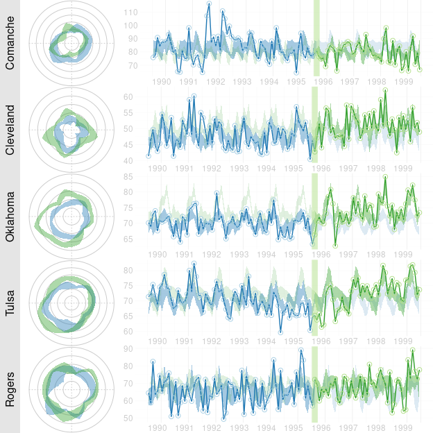

```r
graph_row_comparison <- function( row_label="", county_name="oklahoma", spread_function=h_spread, change_month=as.Date("1996-02-15") ) {
  ds_linear <- ds_linear_all[ds_linear_all$county_name==county_name, ]
  ds_linear <- Wats::augment_year_data_with_month_resolution(ds_linear=ds_linear, date_name="date")
  portfolio_cartesian <- Wats::annotate_data(ds_linear, dv_name="birth_rate", center_function=stats::median, spread_function=spread_function)
  portfolio_polar <- Wats::polarize_cartesian(ds_linear=portfolio_cartesian$ds_linear, ds_stage_cycle=portfolio_cartesian$ds_stage_cycle, y_name="birth_rate", stage_id_name="stage_id", plotted_point_count_per_cycle=7200)
  cartesian_periodic <- Wats::cartesian_periodic(portfolio_cartesian$ds_linear, portfolio_cartesian$ds_periodic, x_name="date", y_name="birth_rate", stage_id_name="stage_id", change_points=change_month, change_point_labels=""  )

  grid::pushViewport(grid::viewport(
    layout=grid::grid.layout(nrow=1, ncol=3, respect=FALSE, widths=grid::unit(c(1.5,1,3), c("line", "null", "null"))),
    gp=grid::gpar(cex=1, fill=NA)
  ))
  grid::pushViewport(grid::viewport(layout.pos.col=1))
  grid.rect(gp=gpar(fill="gray90", col=NA))
  grid.text(row_label, rot=90)
  grid::popViewport()

  grid::pushViewport(grid::viewport(layout.pos.col=2))
  # polar_periodic <-
  Wats::polar_periodic(
    ds_linear               = portfolio_polar$ds_observed_polar,
    ds_stage_cycle_polar    = portfolio_polar$ds_stage_cycle_polar,
    draw_observed_line      = FALSE,
    y_name                  = "radius",
    stage_id_name           = "stage_id",
    origin_label            = NULL,
    plot_margins            = c(0, 0, 0, 0)
  )
  grid::popViewport()

  grid::pushViewport(grid::viewport(layout.pos.col=3))
  print(cartesian_periodic + x_scale + light_theme, vp=vp_layout(x=1, y=1))
  grid::popViewport()
  grid::popViewport() #Finish the row
}

counties <- c("comanche", "cleveland", "oklahoma", "tulsa", "rogers")
county_names <- c("Comanche", "Cleveland", "Oklahoma", "Tulsa", "Rogers")

grid.newpage()
grid::pushViewport(grid::viewport(layout=grid.layout(nrow=length(counties), ncol=1), gp=grid::gpar(cex=1, fill=NA)))
for (i in base::seq_along(counties)) {
  grid::pushViewport(grid::viewport(layout.pos.row=i))
  graph_row_comparison(county_name=counties[i], row_label=county_names[i])
  grid::popViewport()
}
grid::popViewport()
```

Here are all 12 counties that Ronnie collected birth records for. This extended graph is not in the manuscript.

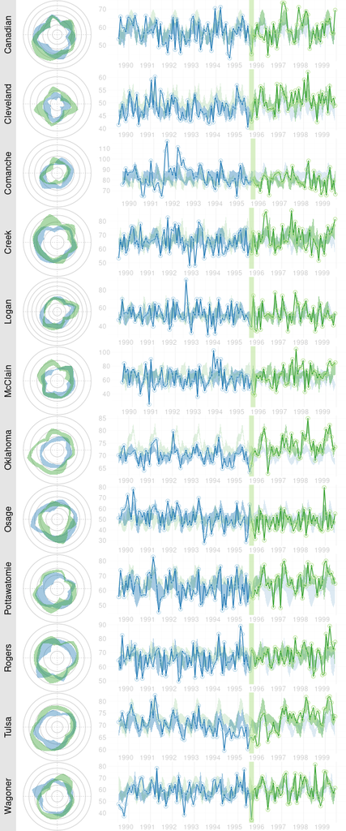

```r
counties <- base::sort(base::unique(ds_linear_all$county_name))
county_names <- c("Canadian", "Cleveland", "Comanche", "Creek", "Logan", "McClain", "Oklahoma", "Osage", "Pottawatomie", "Rogers", "Tulsa", "Wagoner")

grid::grid.newpage()
grid::pushViewport(grid::viewport(layout=grid.layout(nrow=base::length(counties), ncol=1), gp=grid::gpar(cex=1, fill=NA)))
for (i in base::seq_along(counties)) {
  grid::pushViewport(grid::viewport(layout.pos.row=i))
  graph_row_comparison(county_name=counties[i], row_label=county_names[i])
  grid::popViewport()
}
grid::popViewport()
```

## Figure 8: Error Band Comparison

This figure demonstrates that WATS accommodates many types of error bands.

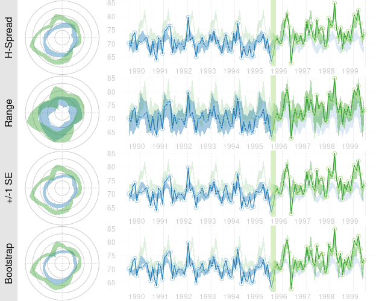

```r
spreads <- c("h_spread", "full_spread", "se_spread", "boot_spread")
spread_names <- c("H-Spread", "Range", "+/-1 SE", "Bootstrap")
grid::grid.newpage()
grid::pushViewport(grid::viewport(layout=grid::grid.layout(nrow=base::length(spreads), ncol=1), gp=grid::gpar(cex=1, fill=NA)))
for (i in base::seq_along(spreads)) {
  grid::pushViewport(grid::viewport(layout.pos.row=i))
  graph_row_comparison(spread_function=base::get(spreads[i]), row_label=spread_names[i])
  grid::upViewport()
}
grid::upViewport()
```

## Session Info

The current vignette was build on a system using the following software.

```
Report created by wibeasley at Fri 03 Mar 2023 10:38:24 AM CST, -0600
```